# test2

# Introduction

## a) Chargement des packages nécessaires

```r
# Charger les packages nécessaires
library(ggplot2)
library(readr)
library(tidyr)
library("FactoMineR")
library("factoextra")
library(tidyverse)
library(GGally)
library(FNN)
library(patchwork)
library(caret)
library(lattice)
library(tree)
library(Metrics)
library(dplyr)
library(e1071)
library(randomForest)
library(FNN)
library(pROC)
```

## b) Chargement des données

```r
df <- read_delim("C:/Users/ranus/OneDrive/Bureau/archive(1)/fake_bills.csv")
df
```

| is_genuine | diagonal | height_left | height_right | margin_low | margin_up | length |
| --- | --- | --- | --- | --- | --- | --- |
| TRUE | 171.81 | 104.86 | 104.95 | 4.52 | 2.89 | 112.83 |
| TRUE | 171.46 | 103.36 | 103.66 | 3.77 | 2.99 | 113.09 |
| TRUE | 172.69 | 104.48 | 103.50 | 4.40 | 2.94 | 113.16 |
| TRUE | 171.36 | 103.91 | 103.94 | 3.62 | 3.01 | 113.51 |
| TRUE | 171.73 | 104.28 | 103.46 | 4.04 | 3.48 | 112.54 |
| TRUE | 172.17 | 103.74 | 104.08 | 4.42 | 2.95 | 112.81 |
| TRUE | 172.34 | 104.18 | 103.85 | 4.58 | 3.26 | 112.81 |
| TRUE | 171.88 | 103.76 | 104.08 | 3.98 | 2.92 | 113.08 |
| TRUE | 172.47 | 103.92 | 103.67 | 4.00 | 3.25 | 112.85 |
| TRUE | 172.47 | 104.07 | 104.02 | 4.04 | 3.25 | 113.45 |

[output cut: 990 more lines]

les vraiables correspondent à :

is_genuine : Le billet est-il authentique ? Vrai faux diagonale : les mesures diagonales en mm height_left : la hauteur du côté gauche en mm height_right : la hauteur du côté droit en mm margin_low : la marge inférieure en mm margin_up : la marge supérieure en mm longueur : la longueur en mm

# A) Analyse descriptive

## 1) Valeurs manquantes

On determine ici le nombres de valeurs manquantes.

```r
sum(is.na(df))
```

```
[1] 37
```

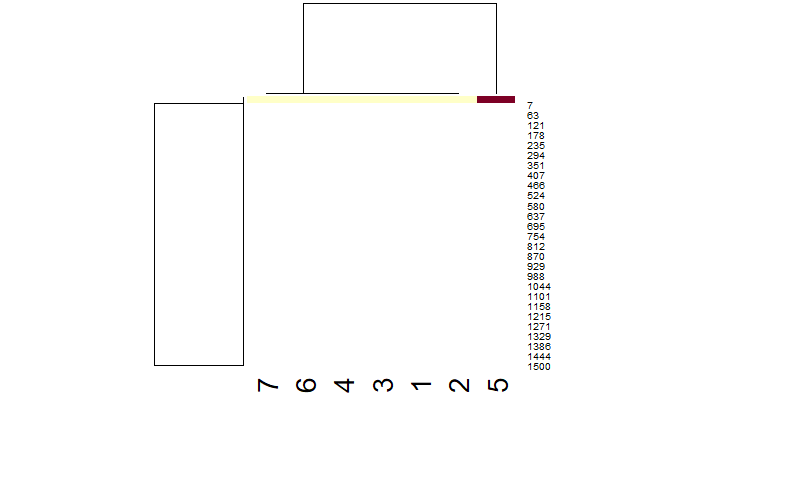

```r
heatmap(matrix(as.numeric(is.na(df)),ncol = 7))
```

Il y a donc dans l’ensemble du data set, 37 valeurs manquantes.

Il faut ensuite déterminer leurs localisations.

```r
count(df,margin_low,sort = TRUE)
```

| margin_low | n |
| --- | --- |
| NA | 37 |
| 4.08 | 20 |
| 4.10 | 20 |
| 4.18 | 20 |
| 4.12 | 18 |
| 4.17 | 18 |
| 4.36 | 17 |
| 3.97 | 16 |
| 4.23 | 16 |
| 4.00 | 15 |

[output cut: 276 more lines]

On remarque que les 37 valeurs manquantes sont toutes présentes au même endroit, elles sont toutes dans la variable margin_low.

Il existe plusieurs méthodes pour remplacer les données manquantes - on peut remplacer par la moyenne - on peut remplacer par la medianne - on peut remplacer par la catégorie dominante - on peut créer une nouvelle catégorie - on peut faire de la régression linéaire - on peut faire du k-mean

```r
cor(df)
```

```
             is_genuine    diagonal height_left
is_genuine    1.0000000  0.13275633 -0.37983292
diagonal      0.1327563  1.00000000  0.01947232
height_left  -0.3798329  0.01947232  1.00000000
height_right -0.4850918 -0.02449201  0.24227881
margin_low           NA          NA          NA
margin_up    -0.6062623 -0.05564888  0.24652224
length        0.8492846  0.09758729 -0.32086276
             height_right margin_low   margin_up
is_genuine    -0.48509183         NA -0.60626226
diagonal      -0.02449201         NA -0.05564888
height_left    0.24227881         NA  0.24652224
height_right   1.00000000         NA  0.30700464
margin_low             NA          1          NA
margin_up      0.30700464         NA  1.00000000
length        -0.40175122         NA -0.52057513
                  length
is_genuine    0.84928463
diagonal      0.09758729
height_left  -0.32086276
height_right -0.40175122
margin_low            NA
margin_up    -0.52057513
length        1.00000000
```

On ne peut pas se prononcer sur les corrélation linéaire entre margin_low et les autres variables. Cependant on remarque que is_genuine est fortement corrélé avec length et anti corrélé avec margin_up

### a) Régression linéaire

Comme vu précemment l’une des variables quantitative possède des valeurs manquantes. Nous allons utiliser une méthode de computation via GLM pour les remplacer. On commencer par isoler les données manquantes, puis nous retirons la variable target pour éviter d’utiliser les variables target pour l’imputation et biaisé la suite de l’étude.

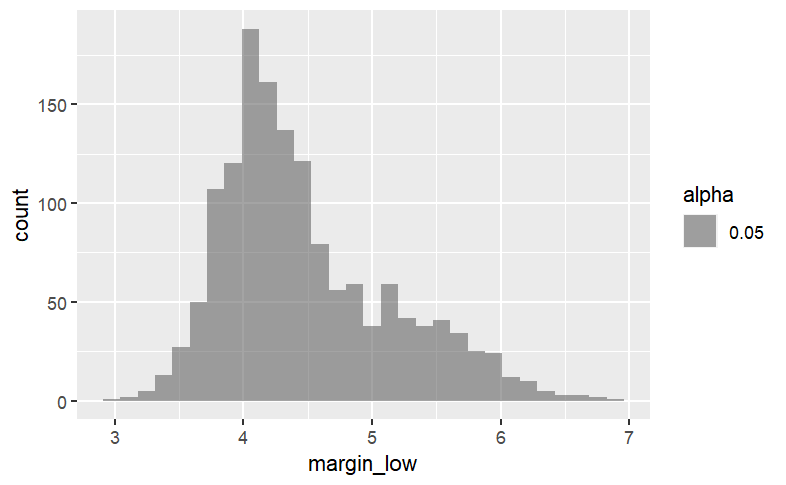

```r
df%>%
  ggplot()+geom_histogram(aes(x=margin_low,alpha=0.05))
```

```r
df_na=df[is.na(df$margin_low),]
df_no_na=na.omit(df)
df_no_na
```

| is_genuine | diagonal | height_left | height_right | margin_low | margin_up | length |
| --- | --- | --- | --- | --- | --- | --- |
| TRUE | 171.81 | 104.86 | 104.95 | 4.52 | 2.89 | 112.83 |
| TRUE | 171.46 | 103.36 | 103.66 | 3.77 | 2.99 | 113.09 |
| TRUE | 172.69 | 104.48 | 103.50 | 4.40 | 2.94 | 113.16 |
| TRUE | 171.36 | 103.91 | 103.94 | 3.62 | 3.01 | 113.51 |
| TRUE | 171.73 | 104.28 | 103.46 | 4.04 | 3.48 | 112.54 |
| TRUE | 172.17 | 103.74 | 104.08 | 4.42 | 2.95 | 112.81 |
| TRUE | 172.34 | 104.18 | 103.85 | 4.58 | 3.26 | 112.81 |
| TRUE | 171.88 | 103.76 | 104.08 | 3.98 | 2.92 | 113.08 |
| TRUE | 172.47 | 103.92 | 103.67 | 4.00 | 3.25 | 112.85 |
| TRUE | 172.47 | 104.07 | 104.02 | 4.04 | 3.25 | 113.45 |

[output cut: 990 more lines]

```r
target_no_na=df_no_na$is_genuine
df_2_no_na=df_no_na[,-1]
```

#### - critère AIC

```r
#target=df$is_genuine
#data=df[,-1]
```

```r
mod0<-glm(margin_low~1,data=df_2_no_na,family='gaussian')
mod1<-glm(margin_low~.,data=df_2_no_na,family='gaussian')
stp<-step(mod0,scope=list(lower=mod0,upper=mod1),direction='both')
```

```
Start:  AIC=2955.87
margin_low ~ 1

               Df Deviance    AIC
+ length        1   357.83 2097.6
+ margin_up     1   524.22 2656.3
+ height_right  1   545.69 2715.0
+ height_left   1   585.22 2817.3
+ diagonal      1   636.21 2939.6
<none>              644.23 2955.9

Step:  AIC=2097.64
margin_low ~ length

               Df Deviance    AIC
+ height_right  1   346.45 2052.4
+ margin_up     1   351.57 2073.8
+ height_left   1   351.64 2074.1
+ diagonal      1   356.55 2094.4
<none>              357.83 2097.6
- length        1   644.23 2955.9

Step:  AIC=2052.37
margin_low ~ length + height_right

               Df Deviance    AIC
+ margin_up     1   342.03 2035.6
+ height_left   1   342.11 2035.9
+ diagonal      1   344.99 2048.2
<none>              346.45 2052.4
- height_right  1   357.83 2097.6
- length        1   545.69 2715.0

Step:  AIC=2035.59
margin_low ~ length + height_right + margin_up

               Df Deviance    AIC
+ height_left   1   338.37 2021.8
+ diagonal      1   340.62 2031.5
<none>              342.03 2035.6
```

[output cut: 11 more lines]

```
- margin_up     1   342.11 2035.9
- height_right  1   346.50 2054.6
- length        1   460.40 2470.4

Step:  AIC=2016.65
margin_low ~ length + height_right + margin_up + height_left +
    diagonal

               Df Deviance    AIC
<none>              336.71 2016.7
- diagonal      1   338.37 2021.8
- margin_up     1   340.37 2030.5
- height_left   1   340.62 2031.5
- height_right  1   344.97 2050.1
- length        1   455.03 2455.2
```

```r
summary(stp)
```

```
Call:
glm(formula = margin_low ~ length + height_right + margin_up +
    height_left + diagonal, family = "gaussian", data = df_2_no_na)

Deviance Residuals:
     Min        1Q    Median        3Q       Max
-1.47234  -0.31707  -0.04168   0.27353   1.97084

Coefficients:
             Estimate Std. Error t value Pr(>|t|)
(Intercept)  22.99484    9.65555   2.382  0.01737
length       -0.40910    0.01808 -22.627  < 2e-16
height_right  0.25714    0.04301   5.978 2.84e-09
margin_up     0.25619    0.06437   3.980 7.23e-05
height_left   0.18412    0.04477   4.113 4.13e-05
diagonal     -0.11106    0.04144  -2.680  0.00744

(Intercept)  *
length       ***
height_right ***
margin_up    ***
height_left  ***
diagonal     **
---
Signif. codes:
0 ‘***’ 0.001 ‘**’ 0.01 ‘*’ 0.05 ‘.’ 0.1 ‘ ’ 1

(Dispersion parameter for gaussian family taken to be 0.2311005)

    Null deviance: 644.23  on 1462  degrees of freedom
Residual deviance: 336.71  on 1457  degrees of freedom
AIC: 2016.6

Number of Fisher Scoring iterations: 2
```

Le meilleur modèle est celui qui minimise l’AIC cet à dire celui de la forme
$$margin_low ~ length +
height_right + margin_up +
height_left + diagonal$$

#### - critère BIC

```r
mod0<-glm(margin_low~1,data=df_2_no_na,family=gaussian)
mod1<-glm(margin_low~.,data=df_2_no_na,family=gaussian)
stp2<-step(mod0,scope=list(lower=mod0,upper=mod1),direction='both',k=log(nrow(df_2_no_na)))
```

```
Start:  AIC=2961.16
margin_low ~ 1

               Df Deviance    AIC
+ length        1   357.83 2108.2
+ margin_up     1   524.22 2666.9
+ height_right  1   545.69 2725.6
+ height_left   1   585.22 2827.9
+ diagonal      1   636.21 2950.1
<none>              644.23 2961.2

Step:  AIC=2108.21
margin_low ~ length

               Df Deviance    AIC
+ height_right  1   346.45 2068.2
+ margin_up     1   351.57 2089.7
+ height_left   1   351.64 2090.0
<none>              357.83 2108.2
+ diagonal      1   356.55 2110.3
- length        1   644.23 2961.2

Step:  AIC=2068.24
margin_low ~ length + height_right

               Df Deviance    AIC
+ margin_up     1   342.03 2056.7
+ height_left   1   342.11 2057.1
<none>              346.45 2068.2
+ diagonal      1   344.99 2069.3
- height_right  1   357.83 2108.2
- length        1   545.69 2725.6

Step:  AIC=2056.74
margin_low ~ length + height_right + margin_up

               Df Deviance    AIC
+ height_left   1   338.37 2048.3
<none>              342.03 2056.7
+ diagonal      1   340.62 2058.0
- margin_up     1   346.45 2068.2
- height_right  1   351.57 2089.7
- length        1   476.64 2535.0

Step:  AIC=2048.28
margin_low ~ length + height_right + margin_up + height_left

               Df Deviance    AIC
<none>              338.37 2048.3
+ diagonal      1   336.71 2048.4
- height_left   1   342.03 2056.7
- margin_up     1   342.11 2057.1
- height_right  1   346.50 2075.7
- length        1   460.40 2491.5
```

```r
summary(stp2)
```

```
Call:
glm(formula = margin_low ~ length + height_right + margin_up +
    height_left, family = gaussian, data = df_2_no_na)

Deviance Residuals:
     Min        1Q    Median        3Q       Max
-1.54265  -0.31879  -0.04392   0.27593   1.99858

Coefficients:
             Estimate Std. Error t value Pr(>|t|)
(Intercept)   5.26563    7.04828   0.747    0.455
length       -0.41364    0.01804 -22.930  < 2e-16
height_right  0.25500    0.04310   5.917 4.09e-09
margin_up     0.25880    0.06450   4.012 6.32e-05
height_left   0.17795    0.04481   3.971 7.49e-05

(Intercept)
length       ***
height_right ***
margin_up    ***
height_left  ***
---
Signif. codes:
0 ‘***’ 0.001 ‘**’ 0.01 ‘*’ 0.05 ‘.’ 0.1 ‘ ’ 1

(Dispersion parameter for gaussian family taken to be 0.2320805)

    Null deviance: 644.23  on 1462  degrees of freedom
Residual deviance: 338.37  on 1458  degrees of freedom
AIC: 2021.8

Number of Fisher Scoring iterations: 2
```

```r
mod3<-glm(margin_low~.,data=df_no_na[-1],family=gaussian)

#On prédit les valeurs manquante avec le glm
imputation_value=predict(mod3,df_na[,-1])

#on remplace la colonne d'origine par la prediction, puis nous fusionnons les observtion sans na et celles qui en avaient
df_na$margin_low=imputation_value #remplacement

df_clean=rbind(df_no_na,df_na)#fusion

set.seed(42)  # melange des samples
rows <- sample(nrow(df_clean))
data <- as.data.frame(df_clean[rows, ])
data
```

| is_genuine | diagonal | height_left | height_right | margin_low | margin_up | length |
| --- | --- | --- | --- | --- | --- | --- |
| TRUE | 172.28 | 104.09 | 104.20 | 3.660000 | 2.83 | 113.48 |
| TRUE | 171.85 | 103.86 | 104.08 | 4.230000 | 3.36 | 113.01 |
| FALSE | 171.96 | 104.38 | 103.82 | 5.190000 | 3.32 | 111.68 |
| FALSE | 172.37 | 104.25 | 103.67 | 5.120000 | 3.30 | 112.03 |
| FALSE | 171.60 | 104.23 | 104.45 | 5.570000 | 3.45 | 110.34 |
| FALSE | 171.85 | 104.12 | 103.69 | 4.860000 | 3.50 | 111.55 |
| TRUE | 171.71 | 103.83 | 103.51 | 3.800000 | 3.02 | 113.01 |
| TRUE | 172.07 | 104.05 | 103.82 | 3.710000 | 3.61 | 113.05 |
| FALSE | 172.25 | 103.96 | 103.92 | 4.670000 | 3.24 | 111.06 |
| FALSE | 171.95 | 104.47 | 104.34 | 5.920000 | 3.10 | 113.17 |

[output cut: 990 more lines]

## 2) Visualisation

### a) Pairplot

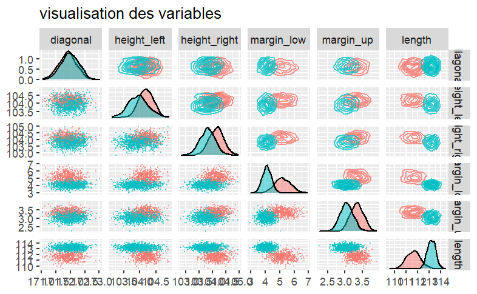

```r
ggpairs(data =data ,
        columns = 2:7,
        title = "visualisation des variables",
        upper = list(continuous = wrap("density", alpha = 0.75), combo = "box_no_facet"),
        lower = list(continuous = wrap("points", alpha = 0.5, size=0.1), combo = "facethist"),
        diag = list(continuous = wrap("densityDiag", alpha = 0.5)),
        progress = FALSE,
        aes(colour=is_genuine))
```

On a représenté l’ensembles des variables en fonctions d’elle même en faisant la distinction de couleur sur l’authenticité des billets.

### b) Boxplot

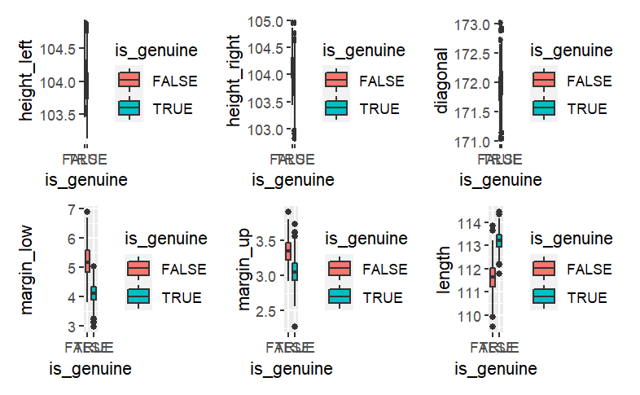

```r
ggplot(data)+geom_boxplot(x="is_genuine",y="height_left")->p
p1 <- ggplot(data, aes(x=is_genuine, y=height_left,fill=is_genuine)) +
  geom_boxplot()

p2 <- ggplot(data, aes(x=is_genuine, y=height_right,fill=is_genuine)) +
  geom_boxplot()

p3 <- ggplot(data, aes(x=is_genuine, y=diagonal,fill=is_genuine)) +
  geom_boxplot()

p4 <- ggplot(data, aes(x=is_genuine, y=margin_low,fill=is_genuine)) +
  geom_boxplot()

p5 <- ggplot(data, aes(x=is_genuine, y=margin_up,fill=is_genuine)) +
  geom_boxplot()

p6 <- ggplot(data, aes(x=is_genuine, y=length,fill=is_genuine)) +
  geom_boxplot()

(p1+p2+p3)/(p4+p5+p6)
```

A l’exception de diagonal, toutes les variables ont un impact sur la variable is_genuine. De plus margin_low,legnth et height_left ont des variances différentes.

```r
bartlett.test(data$margin_low,data$is_genuine)
```

```
    Bartlett test of homogeneity of variances

data:  data$margin_low and data$is_genuine
Bartlett's K-squared = 216.89, df = 1,
p-value < 2.2e-16
```

```r
bartlett.test(data$height_left,data$is_genuine)
```

```
    Bartlett test of homogeneity of variances

data:  data$height_left and data$is_genuine
Bartlett's K-squared = 53.276, df = 1,
p-value = 2.898e-13
```

```r
bartlett.test(data$length,data$is_genuine)
```

```
    Bartlett test of homogeneity of variances

data:  data$length and data$is_genuine
Bartlett's K-squared = 207.23, df = 1,
p-value < 2.2e-16
```

```r
loga<-function(data){
  n=ncol(data)
  for(i in 2:n){
    data[,i]=log(data[,i])
  }
  return(data)
}
log_data=loga(data)
```

```r
bartlett.test(log_data$margin_low,log_data$is_genuine)
```

```
    Bartlett test of homogeneity of variances

data:  log_data$margin_low and log_data$is_genuine
Bartlett's K-squared = 66.719, df = 1,
p-value = 3.131e-16
```

```r
reg1<-lm(margin_low~is_genuine,log_data)
anova(reg1)
```

```
Analysis of Variance Table

Response: margin_low
             Df Sum Sq Mean Sq F value    Pr(>F)
is_genuine    1 18.154 18.1539  2320.7 < 2.2e-16
Residuals  1498 11.718  0.0078

is_genuine ***
Residuals
---
Signif. codes:
0 ‘***’ 0.001 ‘**’ 0.01 ‘*’ 0.05 ‘.’ 0.1 ‘ ’ 1
```

```r
bartlett.test(log_data$height_left,log_data$is_genuine)
```

```
    Bartlett test of homogeneity of variances

data:  log_data$height_left and log_data$is_genuine
Bartlett's K-squared = 54.031, df = 1,
p-value = 1.973e-13
```

```r
reg2<-lm(height_left~is_genuine,log_data)
anova(reg2)
```

```
Analysis of Variance Table

Response: height_left
             Df    Sum Sq   Mean Sq F value
is_genuine    1 0.0017936 0.0017936  252.72
Residuals  1498 0.0106314 0.0000071
              Pr(>F)
is_genuine < 2.2e-16 ***
Residuals
---
Signif. codes:
0 ‘***’ 0.001 ‘**’ 0.01 ‘*’ 0.05 ‘.’ 0.1 ‘ ’ 1
```

```r
bartlett.test(log_data$length,log_data$is_genuine)
```

```
    Bartlett test of homogeneity of variances

data:  log_data$length and log_data$is_genuine
Bartlett's K-squared = 218.01, df = 1,
p-value < 2.2e-16
```

```r
reg3<-lm(length~is_genuine,log_data)
anova(reg3)
```

```
Analysis of Variance Table

Response: length
             Df   Sum Sq  Mean Sq F value
is_genuine    1 0.065261 0.065261  3872.6
Residuals  1498 0.025244 0.000017
              Pr(>F)
is_genuine < 2.2e-16 ***
Residuals
---
Signif. codes:
0 ‘***’ 0.001 ‘**’ 0.01 ‘*’ 0.05 ‘.’ 0.1 ‘ ’ 1
```

On remarque également la présence d’outlier pour toutes les variables.

Deplus la présence d’outliers va guider le choix des modèles à utiliser.

Les modèles composé d’arbre de decision sont robuste aux outliers contrairement aux modèles linéaires.

##3) Valeurs aberrantes ###a) logarithme/standardiser (minimiser l’impacte de ces valeurs)

###b) choix du modèle vis à vis des valeurs abhérentes

##4) rééchantillonnage (parce qu’il y a soit VRAI soit FAUX et les FAUX sont au nombre de 500 sur les 1500 données)

Etant donnée le faible nombre d’observation, nous allons plutôt opter pour une méthode d’oversampling pour remédier au problème.

Pour cela nous allons faire du boostrapping, cependant il faudra faire attention car cette méthode favorise le surajustement.

```r
data_na=data[data$is_genuine==FALSE,]
resample=sample(x = 1:500,size = 400,replace=T)

re_data=data_na[resample,]

data2=rbind(data,re_data)


set.seed(43)  # melange des samples
rows <- sample(nrow(data2))
data2 <- as.data.frame(data2[rows, ])
data2
```

|  | is_genuine | diagonal | height_left | height_right | margin_low | margin_up | length |
| --- | --- | --- | --- | --- | --- | --- | --- |
| 1068 | FALSE | 172.03 | 104.16 | 104.31 | 5.460000 | 3.24 | 112.82 |
| 296 | TRUE | 172.22 | 103.72 | 103.80 | 4.360000 | 3.22 | 112.84 |
| 1001.1 | FALSE | 171.83 | 103.56 | 103.76 | 5.560000 | 3.49 | 110.70 |
| 1173 | TRUE | 171.73 | 103.60 | 103.34 | 3.820000 | 3.15 | 112.89 |
| 66 | TRUE | 172.07 | 103.72 | 103.44 | 4.030000 | 2.90 | 113.55 |
| 773 | TRUE | 172.01 | 104.11 | 103.13 | 4.530000 | 2.96 | 113.45 |
| 1498 | TRUE | 171.85 | 103.66 | 103.90 | 4.160000 | 2.98 | 112.91 |
| 440 | TRUE | 171.62 | 103.40 | 104.05 | 3.530000 | 2.96 | 112.72 |
| 4641 | FALSE | 171.44 | 103.99 | 104.04 | 4.810000 | 3.49 | 111.74 |
| 837.1 | FALSE | 171.91 | 104.28 | 103.86 | 5.480000 | 3.37 | 113.13 |

[output cut: 990 more lines]

```r
#write.csv(data, "C:/Users/ranus/OneDrive/Bureau/DataScience/ProjetM2Stat/Data.csv", row.names=FALSE)
```

#B) Modèles de classifications ##1) Régression logistique

```r
#encodage de la variable target
data2$is_genuine=as.factor(as.integer(data2$is_genuine))
data$is_genuine=as.factor(as.integer(data$is_genuine))

# division des donnée en donnée train et donnée test
test_row=sample(nrow(data)*0.25,replace = FALSE)
data_train=data[-test_row,]
data_test=data[test_row,]

#fitControl=trainControl(method="cv",number=10,savePrediction=TRUE)

#log_reg=glm(is_genuine~.,data=data_train,family = binomial(),method = "glm",trControl=fitControl)

log_reg=glm(is_genuine ~ .,data=data_train,family = binomial((link = "logit")))
as.data.frame(predict(log_reg,data_test),type='response')
```

|  | predict(log_reg, data_test) |
| --- | --- |
| 271 | 8.18614337 |
| 230 | -0.67166800 |
| 306 | 8.41934422 |
| 318 | 6.63139974 |
| 122 | 9.65298164 |
| 225 | 6.65341108 |
| 35 | 4.62183660 |
| 91 | 6.53051436 |
| 277 | 5.51569687 |
| 10 | -3.74925750 |

[output cut: 365 more lines]

```r
summary(log_reg)
```

```
Call:
glm(formula = is_genuine ~ ., family = binomial((link = "logit")),
    data = data_train)

Deviance Residuals:
    Min       1Q   Median       3Q      Max
-3.8643  -0.0016   0.0065   0.0323   2.5005

Coefficients:
              Estimate Std. Error z value Pr(>|z|)
(Intercept)  -174.5168   256.0300  -0.682   0.4955
diagonal       -0.2130     1.1250  -0.189   0.8499
height_left    -1.2164     1.1664  -1.043   0.2970
height_right   -2.1737     1.1096  -1.959   0.0501
margin_low     -5.4460     1.0487  -5.193 2.07e-07
margin_up      -9.6651     2.2479  -4.300 1.71e-05
length          5.5091     0.8439   6.528 6.67e-11

(Intercept)
diagonal
height_left
height_right .
margin_low   ***
margin_up    ***
length       ***
---
Signif. codes:
0 ‘***’ 0.001 ‘**’ 0.01 ‘*’ 0.05 ‘.’ 0.1 ‘ ’ 1

(Dispersion parameter for binomial family taken to be 1)

    Null deviance: 1430.767  on 1124  degrees of freedom
Residual deviance:   74.681  on 1118  degrees of freedom
AIC: 88.681

Number of Fisher Scoring iterations: 10
```

##2) Arbre de classification ###a) hyperparamètres / Cross-validation

```r
#refaire arbre pour diagonal + height_left et un pour diagonal + length
tr<-tree(is_genuine~.,data=data_train,control=tree.control(nobs=nrow(data_train),mincut=5,minsize=10))

y_hat_tr<-predict(tr,newdata=data_test)
```

On obtient des proba. On ne va conserver que les valeurs avec la plus grande proba

```r
n=nrow(y_hat_tr)
y=replicate(n,0)
for(i in 1:n){
  if(y_hat_tr[i,2]>y_hat_tr[i,1]){
    y[i]=1
  }
}
y_hat_tr=y
```

La table de contingence nous montre de très bon resultat pour l’arbre.

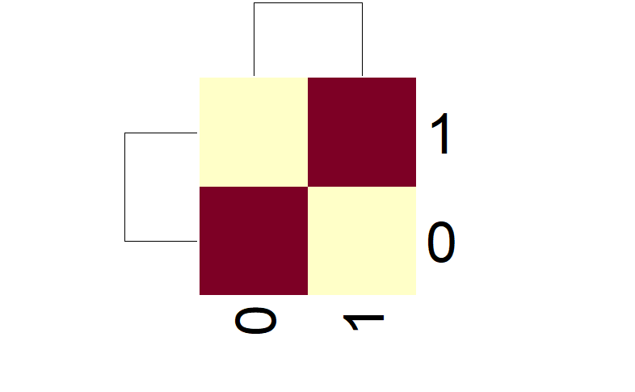

```r
heatmap(table(data_test$is_genuine,y_hat_tr))
```

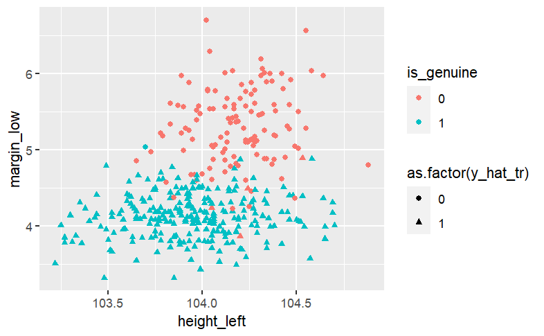

```r
cbind(data_test,y_hat_tr)%>%
  ggplot(aes(x=height_left,y=margin_low,color=is_genuine,shape=as.factor(y_hat_tr)))+geom_point()
```

###b) Métriques d’évaluation

```r
x<-c("modele","accuracy","f1","recall","precision")
tree_metric<-cbind(
  as.data.frame(c("tree")),
  as.data.frame(accuracy(data_test$is_genuine,y_hat_tr)),
  as.data.frame(f1(data_test$is_genuine,y_hat_tr)),
  as.data.frame(recall(data_test$is_genuine,y_hat_tr)),
  as.data.frame(precision(data_test$is_genuine,y_hat_tr)))
colnames(tree_metric) <- x
```

```r
table(data_test$is_genuine,y_hat_tr)
```

```
   y_hat_tr
      0   1
  0 122   4
  1   1 248
```

```r
(122+248)/(122+248+1+4)
```

```
[1] 0.9866667
```

```r
table(as.numeric(data_test$is_genuine),as.numeric(y_hat_tr))
```

```
      0   1
  1 122   4
  2   1 248
```

```r
precision(actual =as.numeric(data_test$is_genuine),predicted = as.numeric(y_hat_tr) )
```

```
[1] 1.984127
```

##3) SVM ###a) hyperparamètres / Cross-validation

```r
k=5
kernels<-c("linear","radial basis","sigmoid",'polynomial')

for(ker in kernels){

  n=nrow(data_train)
  valid_size=n%/%k
  for (i in 1:k){
    d=valid_size*(i-1)
    e=valid_size*i
    valid_data=data_train[c(d:e),]
    data_train2=data_train[-c(d:e),]

    svmfit = svm(is_genuine ~ ., data = data_train2, kernel = kernels, cost = 10, scale = FALSE)
    pred<-predict(svmfit,newdata=valid_data)
    print(paste0('model: SVM  kernel:',ker, "  precision: " ,precision(as.numeric(as.vector(valid_data$is_genuine)),as.numeric(as.vector(pred))),"  recall:", recall(as.numeric(as.vector(valid_data$is_genuine)),as.numeric(as.vector(pred)))))
  }
 print( paste0(" "))
 print( paste0(" "))
 print( paste0(" "))
 print( paste0(" "))
  }
```

```
[1] "model: SVM  kernel:linear  precision: 0.993243243243243  recall:0.986577181208054"
```

```
[1] "model: SVM  kernel:linear  precision: 0.986111111111111  recall:0.986111111111111"
```

```
[1] "model: SVM  kernel:linear  precision: 0.974025974025974  recall:1"
```

```
[1] "model: SVM  kernel:linear  precision: 0.993421052631579  recall:1"
```

```
[1] "model: SVM  kernel:linear  precision: 1  recall:1"
[1] " "
[1] " "
[1] " "
[1] " "
```

```
[1] "model: SVM  kernel:radial basis  precision: 0.993243243243243  recall:0.986577181208054"
```

```
[1] "model: SVM  kernel:radial basis  precision: 0.986111111111111  recall:0.986111111111111"
```

```
[1] "model: SVM  kernel:radial basis  precision: 0.974025974025974  recall:1"
```

```
[1] "model: SVM  kernel:radial basis  precision: 0.993421052631579  recall:1"
```

```
[1] "model: SVM  kernel:radial basis  precision: 1  recall:1"
[1] " "
[1] " "
[1] " "
[1] " "
```

```
[1] "model: SVM  kernel:sigmoid  precision: 0.993243243243243  recall:0.986577181208054"
```

```
[1] "model: SVM  kernel:sigmoid  precision: 0.986111111111111  recall:0.986111111111111"
```

```
[1] "model: SVM  kernel:sigmoid  precision: 0.974025974025974  recall:1"
```

```
[1] "model: SVM  kernel:sigmoid  precision: 0.993421052631579  recall:1"
```

```
[1] "model: SVM  kernel:sigmoid  precision: 1  recall:1"
[1] " "
[1] " "
[1] " "
[1] " "
```

```
[1] "model: SVM  kernel:polynomial  precision: 0.993243243243243  recall:0.986577181208054"
```

```
[1] "model: SVM  kernel:polynomial  precision: 0.986111111111111  recall:0.986111111111111"
```

```
[1] "model: SVM  kernel:polynomial  precision: 0.974025974025974  recall:1"
```

```
[1] "model: SVM  kernel:polynomial  precision: 0.993421052631579  recall:1"
```

```
[1] "model: SVM  kernel:polynomial  precision: 1  recall:1"
[1] " "
[1] " "
[1] " "
[1] " "
```

```r
svmfit = svm(is_genuine ~ ., data = data_train2, kernel = "sigmoid", cost = 10, scale = FALSE)
y_hat_svm<-predict(svmfit,newdata=valid_data)
```

###b) Métriques d’évaluation

```r
tree_metric<-cbind(
  as.data.frame(c("svm")),
  as.data.frame(accuracy(data_test$is_genuine,y_hat_svm)),
  as.data.frame(f1(data_test$is_genuine,y_hat_svm)),
  as.data.frame(recall(data_test$is_genuine,y_hat_svm)),
  as.data.frame(precision(data_test$is_genuine,y_hat_svm)))
```

##4) ACP ###a) hyperparamètres / Cross-validation

[figure not shown]

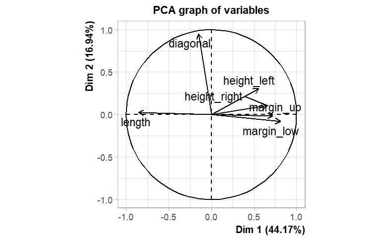

```r
pca=PCA(X = data2[,-1],scale.unit = T)
```

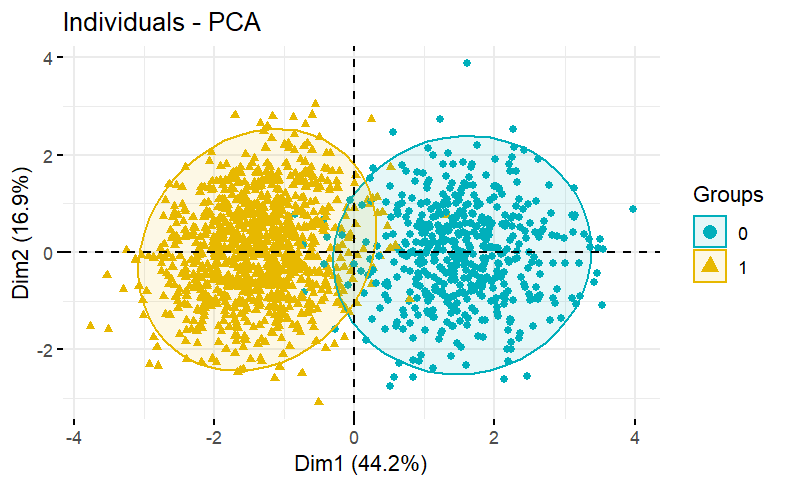

```r
fviz_pca_ind(pca,
             geom.ind = "point", # Montre les points seulement (mais pas le "text")
             col.ind = data2$is_genuine, # colorer by groups
             palette = c("#00AFBB", "#E7B800"),
             addEllipses = TRUE, # Ellipses de concentration
             legend.title = "Groups"
             )
```

##5) Forêt aléatoire  
###a) hyperparamètres / Cross-validation

```r
k=5
ntrees=c(10,50,100)
mtrys=c(1,2,3)

for(ntree in ntrees){
  for(mtry in mtrys){

  n=nrow(data_train)
  valid_size=n%/%k
  for (i in 1:k){
    d=valid_size*(i-1)
    e=valid_size*i
    valid_data=data_train[c(d:e),]
    data_train2=data_train[-c(d:e),]

    rf<-randomForest(is_genuine~.,data=data_train2,mtry=mtry,ntree=ntree)
    pred<-predict(rf,newdata=valid_data)
    print(paste0('model: RandomForest  mtry:',mtry,' ntree: ',ntree, "  precision: " ,precision(as.numeric(as.vector(valid_data$is_genuine)),as.numeric(as.vector(pred))),"  recall:", recall(as.numeric(as.vector(valid_data$is_genuine)),as.numeric(as.vector(pred)))))
  }
 print( paste0(" "))
 print( paste0(" "))
 print( paste0(" "))
 print( paste0(" "))
}}
```

```
[1] "model: RandomForest  mtry:1 ntree: 10  precision: 0.986301369863014  recall:0.966442953020134"
[1] "model: RandomForest  mtry:1 ntree: 10  precision: 0.985915492957746  recall:0.972222222222222"
[1] "model: RandomForest  mtry:1 ntree: 10  precision: 0.967741935483871  recall:1"
[1] "model: RandomForest  mtry:1 ntree: 10  precision: 0.967532467532468  recall:0.986754966887417"
[1] "model: RandomForest  mtry:1 ntree: 10  precision: 1  recall:0.987421383647799"
[1] " "
[1] " "
[1] " "
[1] " "
[1] "model: RandomForest  mtry:2 ntree: 10  precision: 0.993288590604027  recall:0.993288590604027"
[1] "model: RandomForest  mtry:2 ntree: 10  precision: 0.979166666666667  recall:0.979166666666667"
[1] "model: RandomForest  mtry:2 ntree: 10  precision: 0.974025974025974  recall:1"
[1] "model: RandomForest  mtry:2 ntree: 10  precision: 0.993421052631579  recall:1"
[1] "model: RandomForest  mtry:2 ntree: 10  precision: 1  recall:1"
[1] " "
```

[output cut: 66 more lines]

Meilleurs modèle mtry:1 ntree: 50

###b) Métriques d’évaluation

```r
rf<-randomForest(is_genuine~.,data=data_train,mtry=1,ntree=50)
y_hat_rf<-predict(rf,data_test)
cbind(
  as.data.frame(c("random Forest")),
  as.data.frame(accuracy(data_test$is_genuine,y_hat_rf)),
  as.data.frame(f1(data_test$is_genuine,y_hat_rf)),
  as.data.frame(recall(data_test$is_genuine,y_hat_rf)),
  as.data.frame(precision(as.numeric(data_test$is_genuine),as.numeric(y_hat_rf))))
```

| c("random Forest") | accuracy(data_test$is_genuine, y_hat_rf) | f1(data_test$is_genuine, y_hat_rf) | recall(data_test$is_genuine, y_hat_rf) | precision(as.numeric(data_test$is_genuine), as.numeric(y_hat_rf)) |
| --- | --- | --- | --- | --- |
| random Forest | 0.9946667 | 1 | NA | 1.007937 |

##6) KNN ###a) hyperparamètres / Cross-validation

```r
k=5
Kcluster=c(1:5)

for(K in Kcluster){

  n=nrow(data_train)
  valid_size=n%/%k
  for (i in 1:k){
    d=valid_size*(i-1)
    e=valid_size*i
    valid_data=data_train[c(d:e),]
    data_train2=data_train[-c(d:e),]

    pred<-knn(train=as.matrix(data_train2[,-1]),test=as.matrix(valid_data[,-1]),cl =data_train2$is_genuine,k=K)

    print(paste0('model: knn  k:',K, "  precision: " ,precision(as.numeric(as.vector(valid_data$is_genuine)),as.numeric(as.vector(pred))),"  recall:", recall(as.numeric(as.vector(valid_data$is_genuine)),as.numeric(as.vector(pred)))))
  }
 print( paste0(" "))
 print( paste0(" "))
 print( paste0(" "))
 print( paste0(" "))
}
```

```
[1] "model: knn  k:1  precision: 0.993197278911565  recall:0.979865771812081"
[1] "model: knn  k:1  precision: 0.986013986013986  recall:0.979166666666667"
[1] "model: knn  k:1  precision: 0.949367088607595  recall:1"
[1] "model: knn  k:1  precision: 0.986754966887417  recall:0.986754966887417"
[1] "model: knn  k:1  precision: 0.9875  recall:0.993710691823899"
[1] " "
[1] " "
[1] " "
[1] " "
[1] "model: knn  k:2  precision: 0.993197278911565  recall:0.979865771812081"
[1] "model: knn  k:2  precision: 0.985815602836879  recall:0.965277777777778"
[1] "model: knn  k:2  precision: 0.974025974025974  recall:1"
[1] "model: knn  k:2  precision: 0.993288590604027  recall:0.980132450331126"
[1] "model: knn  k:2  precision: 1  recall:0.987421383647799"
[1] " "
```

[output cut: 30 more lines]

```r
knn2<-knn(train=as.matrix(data_train[,-1]),test=as.matrix(data_test[,-1]),cl =data_train$is_genuine,k=2)
```

Il semblerait que le meilleurs k soit 3. Cependant la methode elbow serait peut etre plus adéquat pour trouver le k optimal.

###b) Métriques d’évaluation

```r
knn2<-knn(train=as.matrix(data_train[,-1]),test=as.matrix(data_test[,-1]),cl =data_train$is_genuine,k=3)
accuracy(actual = data_test$is_genuine,predicted = knn2)
```

```
[1] 0.9946667
```

```r
precision(actual = data_test$is_genuine,predicted = knn2)
```

```
[1] NA
```

```r
knn_metric<-cbind(
  as.data.frame(c("knn")),
  as.data.frame(accuracy(data_test$is_genuine,knn2)),
  as.data.frame(f1(as.numeric(as.vector(data_test$is_genuine)),as.numeric(as.vector(knn2)))),
  as.data.frame(recall(as.numeric(as.vector(data_test$is_genuine)),as.numeric(as.vector(knn2)))),
  as.data.frame(precision(as.numeric(as.vector(data_test$is_genuine)),as.numeric(as.vector(knn2)))))


colnames(knn_metric) <- x
knn_metric
```

| modele | accuracy | f1 | recall | precision |
| --- | --- | --- | --- | --- |
| knn | 0.9946667 | 1 | 1 | 0.9920319 |

table de contingence

```r
table(as.vector(data_test$is_genuine),as.vector(knn2))
```

```
      0   1
  0 124   2
  1   0 249
```

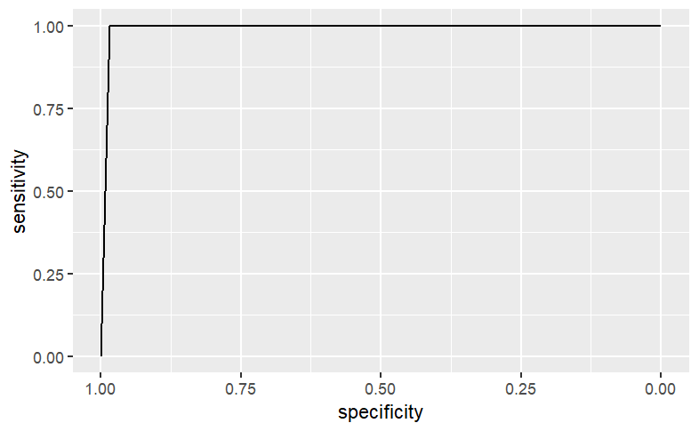

```r
rocobj <- roc(as.numeric(data_test$is_genuine), as.numeric(knn2))
#create ROC plot
ggroc(rocobj)
```

#C) Conclusion

#D) Bibliographie

https://stackoverflow.com/questions/19400494/running-a-stepwise-linear-model-with-bic-criterion

```r
actual <- c(1, 1, 1, 0, 0, 0)
predicted <- c(1, 1, 1, 1, 1, 1)
table(actual, predicted)
```

```
      predicted
actual 1
     0 3
     1 3
```

```r
k=5
ntrees=c(10,50,100)
mtrys=c(1,2,3)

for(ntree in ntrees){
  for(mtry in mtrys){

  n=nrow(data_train)
  valid_size=n%/%k
  for (i in 1:k){
    d=valid_size*(i-1)
    e=valid_size*i
    valid_data=data_train[c(d:e),]
    data_train2=data_train[-c(d:e),]

    rf<-randomForest(is_genuine~.,data=data_train2,mtry=mtry,ntree=ntree)
    pred<-predict(rf,newdata=valid_data)
    print(paste0('model: RandomForest  mtry:',mtry,' ntree: ',ntree, "  precision: " ,precision(as.numeric(as.vector(valid_data$is_genuine)),as.numeric(as.vector(pred))),"  recall:", recall(as.numeric(as.vector(valid_data$is_genuine)),as.numeric(as.vector(pred)))))
  }
 print( paste0(" "))
 print( paste0(" "))
 print( paste0(" "))
 print( paste0(" "))
}}
```

```
[1] "model: RandomForest  mtry:1 ntree: 10  precision: 0.993197278911565  recall:0.979865771812081"
[1] "model: RandomForest  mtry:1 ntree: 10  precision: 0.972222222222222  recall:0.972222222222222"
[1] "model: RandomForest  mtry:1 ntree: 10  precision: 0.961538461538462  recall:1"
[1] "model: RandomForest  mtry:1 ntree: 10  precision: 0.986842105263158  recall:0.993377483443709"
[1] "model: RandomForest  mtry:1 ntree: 10  precision: 1  recall:1"
[1] " "
[1] " "
[1] " "
[1] " "
[1] "model: RandomForest  mtry:2 ntree: 10  precision: 0.993288590604027  recall:0.993288590604027"
[1] "model: RandomForest  mtry:2 ntree: 10  precision: 0.979310344827586  recall:0.986111111111111"
[1] "model: RandomForest  mtry:2 ntree: 10  precision: 0.974025974025974  recall:1"
[1] "model: RandomForest  mtry:2 ntree: 10  precision: 1  recall:0.993377483443709"
[1] "model: RandomForest  mtry:2 ntree: 10  precision: 1  recall:0.993710691823899"
[1] " "
```

[output cut: 66 more lines]

Meilleurs modèle mtry:1 ntree: 50

```r
k=5
kernels<-c("linear","radial basis","sigmoid",'polynomial')

for(ker in kernels){

  n=nrow(data_train)
  valid_size=n%/%k
  for (i in 1:k){
    d=valid_size*(i-1)
    e=valid_size*i
    valid_data=data_train[c(d:e),]
    data_train2=data_train[-c(d:e),]

    svmfit = svm(is_genuine ~ ., data = data_train2, kernel = kernels, cost = 10, scale = FALSE)
    pred<-predict(svmfit,newdata=valid_data)
    print(paste0('model: SVM  kernel:',ker, "  precision: " ,precision(as.numeric(as.vector(valid_data$is_genuine)),as.numeric(as.vector(pred))),"  recall:", recall(as.numeric(as.vector(valid_data$is_genuine)),as.numeric(as.vector(pred)))))
  }
 print( paste0(" "))
 print( paste0(" "))
 print( paste0(" "))
 print( paste0(" "))
  }
```

```
[1] "model: SVM  kernel:linear  precision: 0.993243243243243  recall:0.986577181208054"
```

```
[1] "model: SVM  kernel:linear  precision: 0.986111111111111  recall:0.986111111111111"
```

```
[1] "model: SVM  kernel:linear  precision: 0.974025974025974  recall:1"
```

```
[1] "model: SVM  kernel:linear  precision: 0.993421052631579  recall:1"
```

```
[1] "model: SVM  kernel:linear  precision: 1  recall:1"
[1] " "
[1] " "
[1] " "
[1] " "
```

```
[1] "model: SVM  kernel:radial basis  precision: 0.993243243243243  recall:0.986577181208054"
```

```
[1] "model: SVM  kernel:radial basis  precision: 0.986111111111111  recall:0.986111111111111"
```

```
[1] "model: SVM  kernel:radial basis  precision: 0.974025974025974  recall:1"
```

```
[1] "model: SVM  kernel:radial basis  precision: 0.993421052631579  recall:1"
```

```
[1] "model: SVM  kernel:radial basis  precision: 1  recall:1"
[1] " "
[1] " "
[1] " "
[1] " "
```

```
[1] "model: SVM  kernel:sigmoid  precision: 0.993243243243243  recall:0.986577181208054"
```

```
[1] "model: SVM  kernel:sigmoid  precision: 0.986111111111111  recall:0.986111111111111"
```

```
[1] "model: SVM  kernel:sigmoid  precision: 0.974025974025974  recall:1"
```

```
[1] "model: SVM  kernel:sigmoid  precision: 0.993421052631579  recall:1"
```

```
[1] "model: SVM  kernel:sigmoid  precision: 1  recall:1"
[1] " "
[1] " "
[1] " "
[1] " "
```

```
[1] "model: SVM  kernel:polynomial  precision: 0.993243243243243  recall:0.986577181208054"
```

```
[1] "model: SVM  kernel:polynomial  precision: 0.986111111111111  recall:0.986111111111111"
```

```
[1] "model: SVM  kernel:polynomial  precision: 0.974025974025974  recall:1"
```

```
[1] "model: SVM  kernel:polynomial  precision: 0.993421052631579  recall:1"
```

```
[1] "model: SVM  kernel:polynomial  precision: 1  recall:1"
[1] " "
[1] " "
[1] " "
[1] " "
```

```r
k=5
Kcluster=c(1:5)

for(K in Kcluster){

  n=nrow(data_train)
  valid_size=n%/%k
  for (i in 1:k){
    d=valid_size*(i-1)
    e=valid_size*i
    valid_data=data_train[c(d:e),]
    data_train2=data_train[-c(d:e),]

    pred<-knn(train=as.matrix(data_train2[,-1]),test=as.matrix(valid_data[,-1]),cl =data_train2$is_genuine,k=K)

    print(paste0('model: knn  k:',K, "  precision: " ,precision(as.numeric(as.vector(valid_data$is_genuine)),as.numeric(as.vector(pred))),"  recall:", recall(as.numeric(as.vector(valid_data$is_genuine)),as.numeric(as.vector(pred)))))
  }
 print( paste0(" "))
 print( paste0(" "))
 print( paste0(" "))
 print( paste0(" "))
}
```

```
[1] "model: knn  k:1  precision: 0.993197278911565  recall:0.979865771812081"
[1] "model: knn  k:1  precision: 0.986013986013986  recall:0.979166666666667"
[1] "model: knn  k:1  precision: 0.949367088607595  recall:1"
[1] "model: knn  k:1  precision: 0.986754966887417  recall:0.986754966887417"
[1] "model: knn  k:1  precision: 0.9875  recall:0.993710691823899"
[1] " "
[1] " "
[1] " "
[1] " "
[1] "model: knn  k:2  precision: 0.993197278911565  recall:0.979865771812081"
[1] "model: knn  k:2  precision: 0.985815602836879  recall:0.965277777777778"
[1] "model: knn  k:2  precision: 0.974025974025974  recall:1"
[1] "model: knn  k:2  precision: 0.993288590604027  recall:0.980132450331126"
[1] "model: knn  k:2  precision: 1  recall:0.987421383647799"
[1] " "
```

[output cut: 30 more lines]

```r
knn2<-knn(train=as.matrix(data_train[,-1]),test=as.matrix(data_test[,-1]),cl =data_train$is_genuine,k=2)
```

Il semblerait que le meilleurs k soit 3. Cependant la methode elbow serait peut etre plus adéquat pour trouver le k optimal.